# Final_project_math156

Mo Pei

Wednesday, May 04, 2016

install.packages(“dplyr”) install.packages(“caret”) install.packages(“ordinal”) install.packages(“e1071”) install.packages(“ROCR”) install.packages(“TeachingDemos”) install.packages(“visreg”) install.packages(“influence.ME”) install.packages(“mosaic”) install.packages(“mosaicData”) install.packages(“Lock5Data”) install.packages(“GGally”)

```r
library(GGally)
library(dplyr)
library(caret)
library(ordinal)
library(e1071)
library(ROCR)
library(TeachingDemos)
library(splines)
require(visreg)
library(lme4)
```

```r
library(mosaic)
library(mosaicData)
library(Lock5Data)
```

Salaries for Professors Description

The 2008-09 nine-month academic salary for Assistant Professors, Associate Professors and Professors in a college in the U.S. The data were collected as part of the on-going effort of the college’s administration to monitor salary differences between male and female faculty members.

Data Format

A data frame with 397 observations on the following 6 variables.

rank a factor with levels AssocProf AsstProf Prof

discipline (categorical) a factor with levels A (“theoretical” departments) or B (“applied” departments).

yrs.since.phd (numeric) years since PhD.

yrs.service (numeric) years of service.

sex (categorical) a factor with levels Female Male

salary (numeric) nine-month salary, in dollars.

References Fox J. and Weisberg, S. (2011) An R Companion to Applied Regression, Second Edition Sage.

```r
Salaries <- read.csv("C:/Users/peimo/Desktop/MATH 156/Final_Project/Data/Salaries.csv")
```

1. Two sample T-test & T confidence interval
1. Two sample T-test salaryy mean difference between of theoretical professors and “applied” departments professors

```r
PS_t<-subset(Salaries,select=salary,subset=(discipline=='A'&rank=='Prof'))
PS_a<-subset(Salaries,select=salary,subset=(discipline=='B'&rank=='Prof'))

nrow(PS_t)
```

```
## [1] 131
```

```r
nrow(PS_a)
```

```
## [1] 135
```

```r
choose_range_t<-c(1:nrow(PS_t))
sample_index<-sample(choose_range_t,40)
sample_PS_t<-PS_t[sample_index,]

choose_range_a<-c(1:nrow(PS_a))
sample_index<-sample(choose_range_a,40)
sample_PS_a<-PS_a[sample_index,]

sample_salaries<-data.frame(sample_PS_t,sample_PS_a)
colnames(sample_salaries) <- c("t","a")
```

Two sample T-Test to test if mean of theoretical professors is different from B “applied” departments professors.

Assumtions verification The populations from which the samples have been drawn should be normal

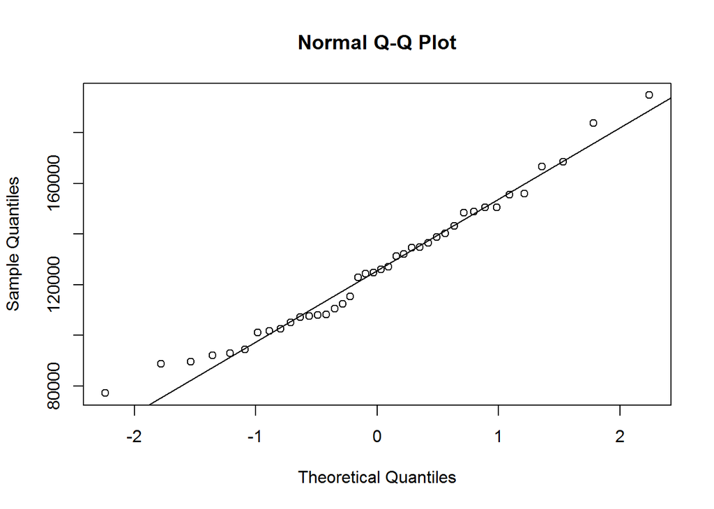

```r
qqnorm(sample_salaries$t)
qqline(sample_salaries$t)
```

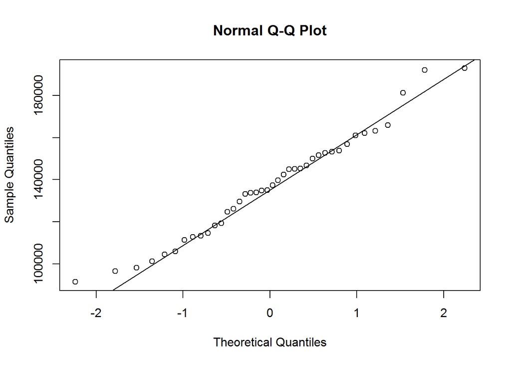

```r
qqnorm(sample_salaries$a)
qqline(sample_salaries$a)
```

The variance of the two groups should be similar

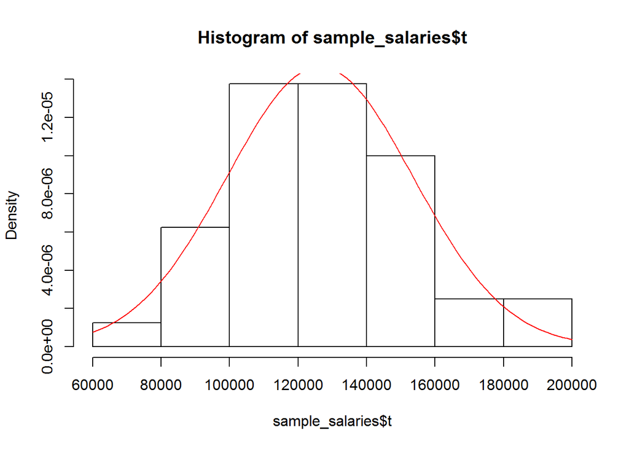

```r
hist(sample_salaries$t, probability = TRUE)
curve(dnorm(x, mean=mean(sample_salaries$t),sd=sd(sample_salaries$t))
      , col = "red", add= TRUE)
```

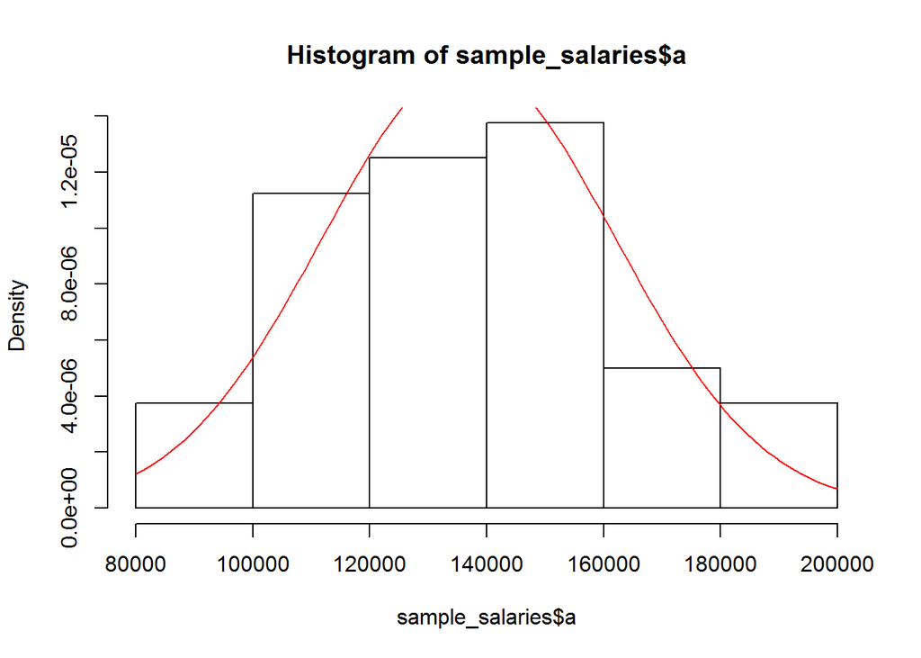

```r
hist(sample_salaries$a, probability = TRUE)
curve(dnorm(x, mean=mean(sample_salaries$a),sd=sd(sample_salaries$a))
      , col = "red", add= TRUE)
```

Each professors salary is independent to each other

Samples have to be randomly selected.

```r
t.test(sample_salaries$t,sample_salaries$a,alt="greater")
```

```
##
##  Welch Two Sample t-test
##
## data:  sample_salaries$t and sample_salaries$a
## t = -1.8052, df = 77.508, p-value = 0.9625
## alternative hypothesis: true difference in means is greater than 0
## 95 percent confidence interval:
##  -20338.77       Inf
## sample estimates:
## mean of x mean of y
##  126363.1  136944.2
```

salaryy mean difference between of male professors and female professors

I am interested to test if female professors make similar amount of salary as male professors do

```r
PS_t<-subset(Salaries,select=salary,
             subset=(sex=='Male'&rank=='Prof')|(sex=='Male'&rank=='AssocProf'))

PS_a<-subset(Salaries,select=salary,
             subset=(sex=='Female'&rank=='Prof')|(sex=='Female'&rank=='AssocProf'))
```

```r
choose_range_t<-c(1:nrow(PS_t))
sample_index<-sample(choose_range_t,28)
sample_PS_t<-PS_t[sample_index,]


sample_PS_a<-PS_a


sample_salaries<-data.frame(sample_PS_t,sample_PS_a)
colnames(sample_salaries) <- c("t","a")
```

Assumtions verification samples have to be randomly drawn independent of each other. I assume the salary of different professors is independent of each other

The populations from which the samples have been drawn should be normal

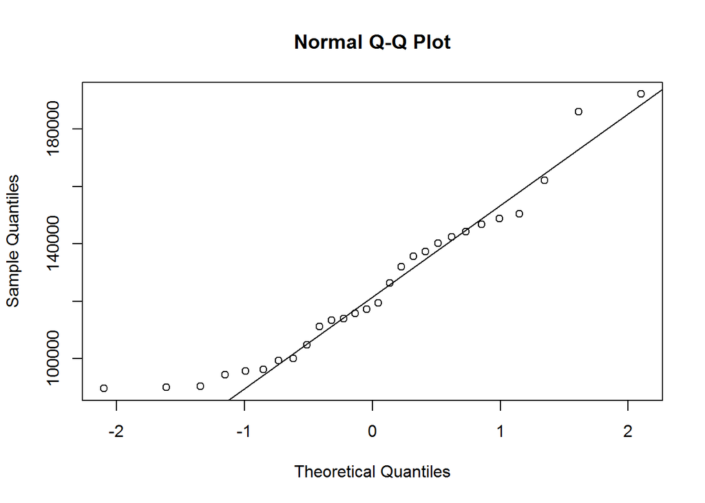

```r
qqnorm(sample_salaries$t)
qqline(sample_salaries$t)
```

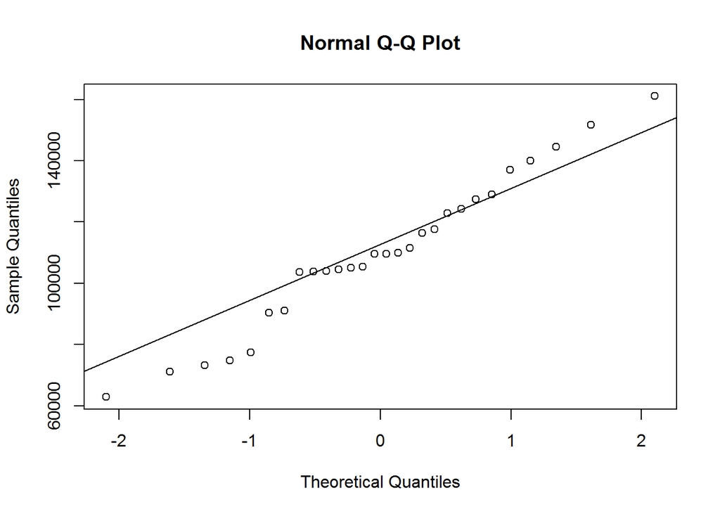

```r
qqnorm(sample_salaries$a)
qqline(sample_salaries$a)
```

The standard deviation of the populations should be equal

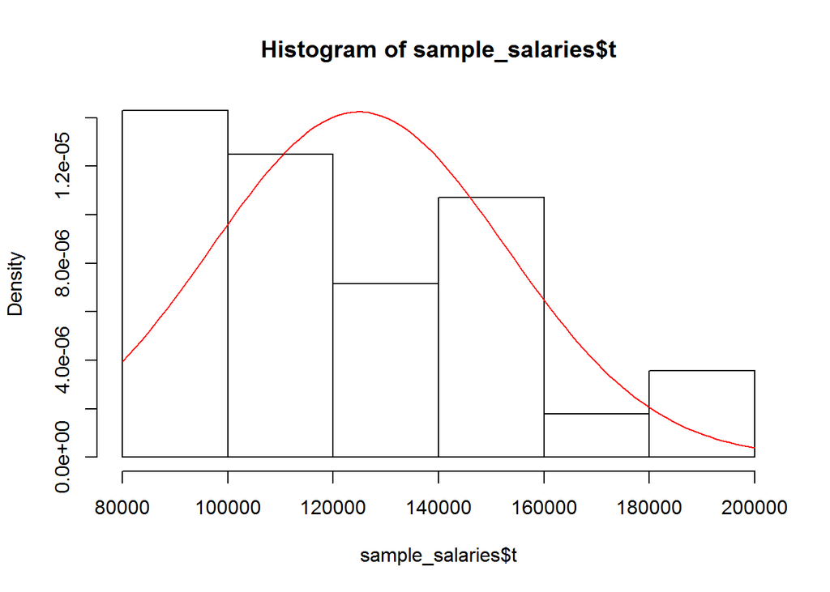

```r
hist(sample_salaries$t, probability = TRUE)
curve(dnorm(x, mean=mean(sample_salaries$t),sd=sd(sample_salaries$t))
      , col = "red", add= TRUE)
```

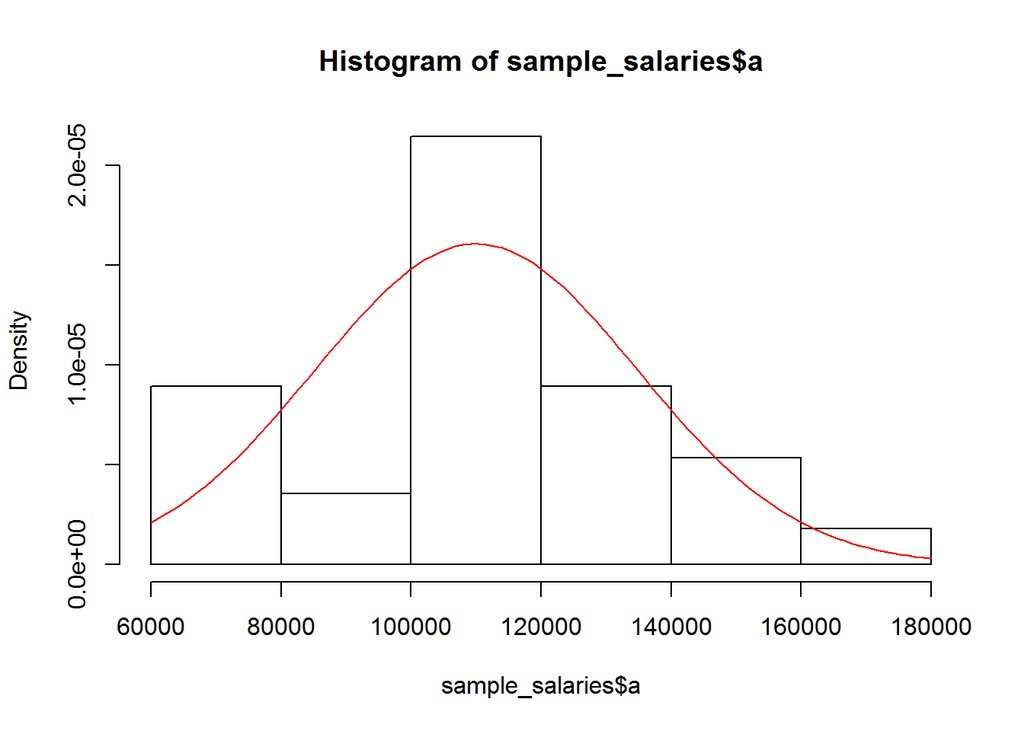

```r
hist(sample_salaries$a, probability = TRUE)
curve(dnorm(x, mean=mean(sample_salaries$a),sd=sd(sample_salaries$a))
      , col = "red", add= TRUE)
```

```r
t.test(sample_salaries$t,sample_salaries$a,alt="greater")
```

```
##
##  Welch Two Sample t-test
##
## data:  sample_salaries$t and sample_salaries$a
## t = 2.0969, df = 53.233, p-value = 0.02038
## alternative hypothesis: true difference in means is greater than 0
## 95 percent confidence interval:
##  2991.587      Inf
## sample estimates:
## mean of x mean of y
##  124852.1  110019.5
```

2. T confidence interval 95% confidence interval of mean of salary of male full professor

I will build t confidence interval to estimate the mean of male professors

```r
PS_m<-subset(Salaries,select=salary,subset=(sex=='Male'&rank=='Prof'))
```

Assumtions verification Samples have to be randomly drawn independent of each other. I assume the salary of different professors is independent of each other

Randomization Condition The data must be sampled randomly.

The populations from which the samples have been drawn should be normal

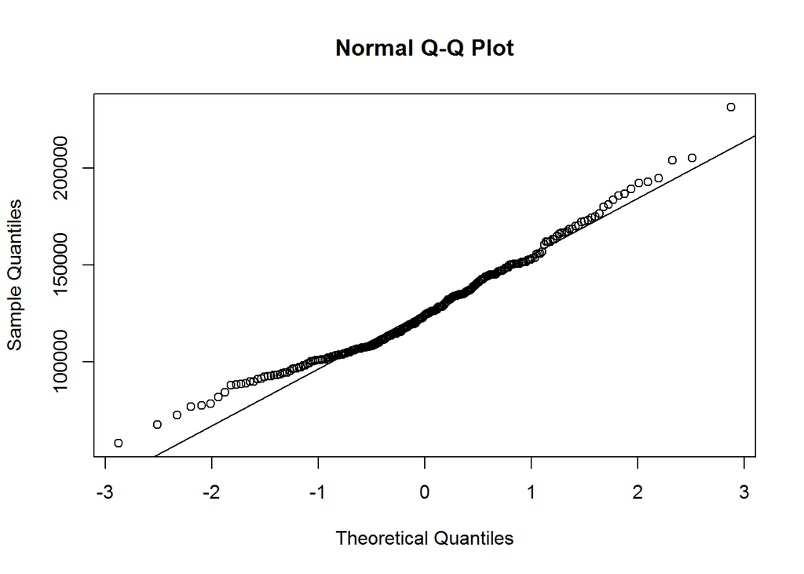

```r
qqnorm(PS_m$salary)
qqline(PS_m$salary)
```

The standard deviation of the populations should be equal

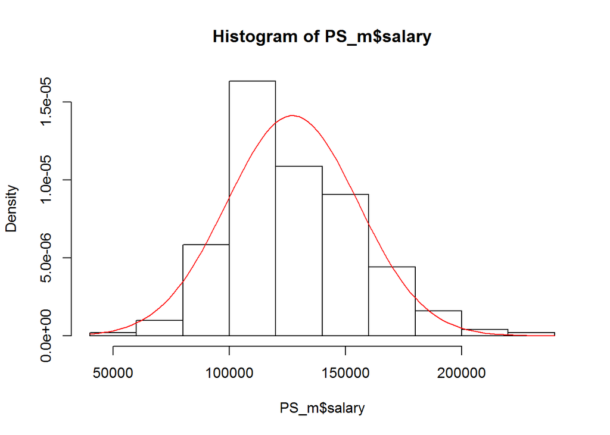

```r
hist(PS_m$salary, probability = TRUE)
curve(dnorm(x, mean=mean(PS_m$salary),sd=sd(PS_m$salary))
      , col = "red", add= TRUE)
```

```r
mean(PS_m$salary)
```

```
## [1] 127120.8
```

```r
nrow(PS_m)
```

```
## [1] 248
```

[figure not shown]

```r
plot(x =c(110000,145000), y = c(1,100), type = "n", xlab = "", ylab = "")
```

blank plot

```r
mean(PS_m$salary); var(PS_m$salary)
```

```
## [1] 127120.8
```

```
## [1] 796018943
```

Use Student’s t(theoritical) to get a confidence interval

```r
mean(PS_m$salary) + qt(0.025, 247) * sd(PS_m$salary)/sqrt(248); mean(PS_m$salary) + qt(0.975, 247) * sd(PS_m$salary)/sqrt(248)
```

```
## [1] 123592.1
```

```
## [1] 130649.5
```

Run the automated t test

```r
t.test(PS_m$salary, conf.level = .95)
```

```
##
##  One Sample t-test
##
## data:  PS_m$salary
## t = 70.955, df = 247, p-value < 2.2e-16
## alternative hypothesis: true mean is not equal to 0
## 95 percent confidence interval:
##  123592.1 130649.5
## sample estimates:
## mean of x
##  127120.8
```

We are 95% percent sure that the true mean of mean of salary of male full professor is between 123592.and 1 130649.5

# Simple linear regression

I am interested to check if there is a relationship between professors’ salary and experince

I especially choose professors and Assocociate professors

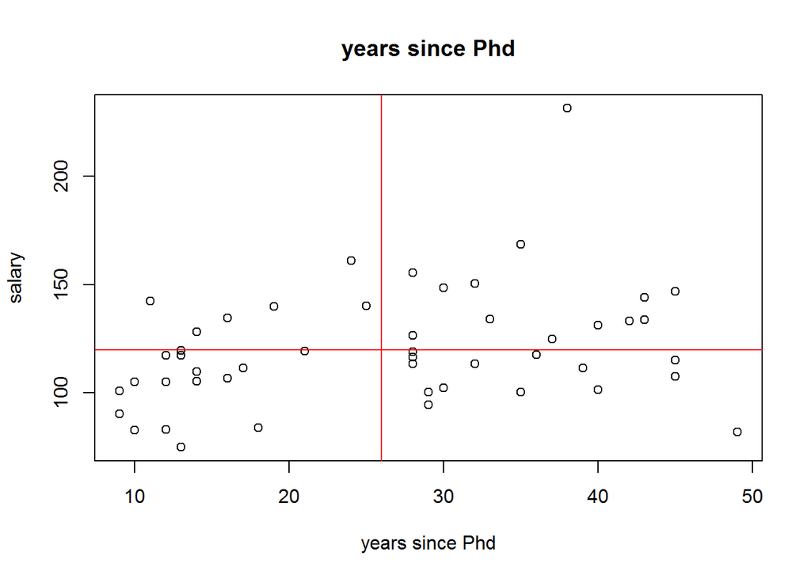

```r
yrs_since_phd<-subset(Salaries,select=yrs.since.phd,subset=((rank=='Prof'))|
                        ((rank=='AssocProf')))
salary<-subset(Salaries,select=salary,subset=((rank=='Prof'))|
                 ((rank=='AssocProf')))

#scaled by divided by 1000
scale_salary<-salary/1000

yrs_phd_salary<-data.frame(yrs_since_phd,scale_salary)
colnames(yrs_phd_salary) <- c("years.since.Phd","scaled.salary")

choose_range_t<-c(1:nrow(PS_t))
sample_index<-sample(choose_range_t,50)
yrs_phd_salary<-yrs_phd_salary[sample_index,]

plot(yrs_phd_salary$years.since.Phd,yrs_phd_salary$scaled.salary,main="years since Phd",xlab = 'years since Phd'
     ,ylab = 'salary')

abline(h = mean(yrs_phd_salary$scaled.salary), col = "red")
abline(v = mean(yrs_phd_salary$years.since.Phd), col = "red")
```

```r
cor.test(yrs_phd_salary$years.since.Phd,yrs_phd_salary$scaled.salary)
```

```
##
##  Pearson's product-moment correlation
##
## data:  yrs_phd_salary$years.since.Phd and yrs_phd_salary$scaled.salary
## t = 2.3992, df = 48, p-value = 0.02036
## alternative hypothesis: true correlation is not equal to 0
## 95 percent confidence interval:
##  0.05378558 0.55502735
## sample estimates:
##       cor
## 0.3272342
```

from Pearson’s product-moment correlation I can see there is a positive correlation betwween professors’ salary and experince.

```r
hb_m.lm <- lm(scaled.salary~ years.since.Phd,data=yrs_phd_salary);hb_m.lm
```

```
##
## Call:
## lm(formula = scaled.salary ~ years.since.Phd, data = yrs_phd_salary)
##
## Coefficients:
##     (Intercept)  years.since.Phd
##         100.841            0.731
```

Appropriate use of novel statistics (eg, trimmed mean, skewness, median absolutedeviation, least-absolute-error regression, ratios, order statistics, R squared)

```r
summary(hb_m.lm)
```

```
##
## Call:
## lm(formula = scaled.salary ~ years.since.Phd, data = yrs_phd_salary)
##
## Residuals:
##     Min      1Q  Median      3Q     Max
## -54.857 -17.799  -2.657  11.041 102.928
##
## Coefficients:
##                 Estimate Std. Error t value Pr(>|t|)
## (Intercept)     100.8405     8.7216  11.562 1.77e-15 ***
## years.since.Phd   0.7310     0.3047   2.399   0.0204 *
## ---
## Signif. codes:  0 '***' 0.001 '**' 0.01 '*' 0.05 '.' 0.1 ' ' 1
##
## Residual standard error: 25.99 on 48 degrees of freedom
## Multiple R-squared:  0.1071, Adjusted R-squared:  0.08848
## F-statistic: 5.756 on 1 and 48 DF,  p-value: 0.02036
```

simple linear regression assumptions verification A graphical display unlike one presented in the textbook or course scripts

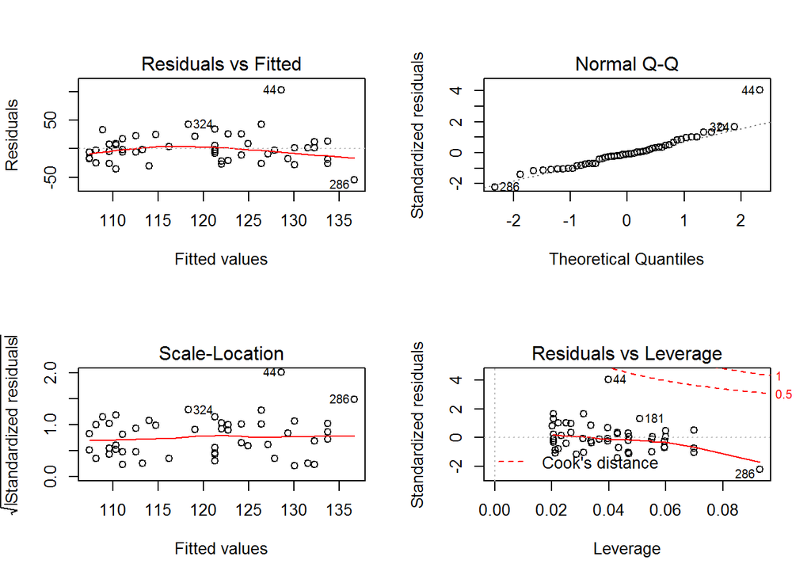

```r
par(mfrow = c(2, 2))
plot(hb_m.lm)
```

```r
par(mfrow = c(1, 1))
```

```r
lowerq = quantile(yrs_phd_salary$scaled.salary)[2]
upperq = quantile(yrs_phd_salary$scaled.salary)[4]
iqr = upperq - lowerq #Or use IQR(data)
# Compute the bounds for a mild outlier:

mild.threshold.upper = (iqr * 1.5) + upperq;mild.threshold.upper
```

```
##      75%
## 180.4231
```

```r
mild.threshold.lower = lowerq - (iqr * 1.5);mild.threshold.lower
```

```
##      25%
## 56.42812
```

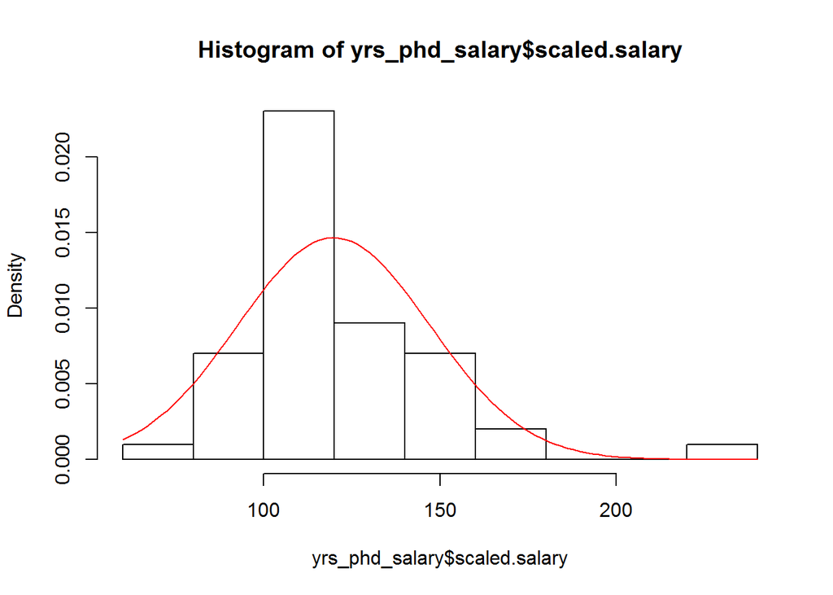

```r
hist(yrs_phd_salary$scaled.salary,probability = TRUE)
curve(dnorm(x, mean=mean(yrs_phd_salary$scaled.salary),sd=sd(yrs_phd_salary$scaled.salary))
      , col = "red", add= TRUE)
```